# Term diposits campaign

Jose M Sallan

22 de octubre de 2019

# 1 Objective of the analysis

We want to answer the following question:

Which kind of customers are most likely to subscribe (yes/no) a term deposit (variable y)?

This means that we need to build a model to predict if a customer will suscribe a term deposit.

# 2 Methdology

## 2.1 The dataset

The variables in our dataset are:

1. age (numeric)
2. job: type of job (categorical)
3. marital: marital status (categorical)
4. education: educational level (categorical)
5. default: has credit in default? (binary)
6. balance: average yearly balance, in euros (numeric)
7. housing: has housing loan? (binary)
8. loan: has personal loan? (binary) From here, information related with the last contact of the current campaign:
9. contact: contact communication type (categorical)
10. day: last contact day of the month (numeric)
11. month: last contact month of year (categorical)
12. duration: last contact duration, in seconds (numeric) Other attributes to consider:
13. campaign: number of contacts performed during this campaign and for this client (numeric)
14. pdays: number of days that passed by after the client was last contacted from a previous campaign (numeric, -1 means client was not previously contacted)
15. previous: number of contacts performed before this campaign and for this client (numeric)
16. poutcome: outcome of the previous marketing campaign (categorical) Output variable (desired target):
17. y: has the client subscribed a term deposit? (binary)

We can classify the variables as follows:

- Demographics (variables 1 to 4)
- Description of each individual as a customer (variables 5 to 8)
- Impact of campaign on customer (variables 9 to 14)
- Impact of previous campaigns on customer (variables 14 a 16)
- Target variable (variable 17)

# 3 Results

## 3.1 Examining data

We will start loading the data into R being categorical variables as factors, and summarise the resulting data frame:

```r
library(dplyr)
library(tidyr)
library(ggplot2)
library(gridExtra)
```

```r
banks <- read.csv2("bank.csv")
summary(banks)
```

```
##       age                 job          marital         education
##  Min.   :19.00   management :969   divorced: 528   primary  : 678
##  1st Qu.:33.00   blue-collar:946   married :2797   secondary:2306
##  Median :39.00   technician :768   single  :1196   tertiary :1350
##  Mean   :41.17   admin.     :478                   unknown  : 187
##  3rd Qu.:49.00   services   :417
##  Max.   :87.00   retired    :230
##                  (Other)    :713
##  default       balance      housing     loan           contact
##  no :4445   Min.   :-3313   no :1962   no :3830   cellular :2896
##  yes:  76   1st Qu.:   69   yes:2559   yes: 691   telephone: 301
##             Median :  444                         unknown  :1324
##             Mean   : 1423
##             3rd Qu.: 1480
##             Max.   :71188
##
##       day            month         duration       campaign
##  Min.   : 1.00   may    :1398   Min.   :   4   Min.   : 1.000
##  1st Qu.: 9.00   jul    : 706   1st Qu.: 104   1st Qu.: 1.000
##  Median :16.00   aug    : 633   Median : 185   Median : 2.000
##  Mean   :15.92   jun    : 531   Mean   : 264   Mean   : 2.794
##  3rd Qu.:21.00   nov    : 389   3rd Qu.: 329   3rd Qu.: 3.000
##  Max.   :31.00   apr    : 293   Max.   :3025   Max.   :50.000
##                  (Other): 571
##      pdays           previous          poutcome      y
##  Min.   : -1.00   Min.   : 0.0000   failure: 490   no :4000
##  1st Qu.: -1.00   1st Qu.: 0.0000   other  : 197   yes: 521
##  Median : -1.00   Median : 0.0000   success: 129
##  Mean   : 39.77   Mean   : 0.5426   unknown:3705
##  3rd Qu.: -1.00   3rd Qu.: 0.0000
##  Max.   :871.00   Max.   :25.0000
##
```

### 3.1.1 Demographic variables

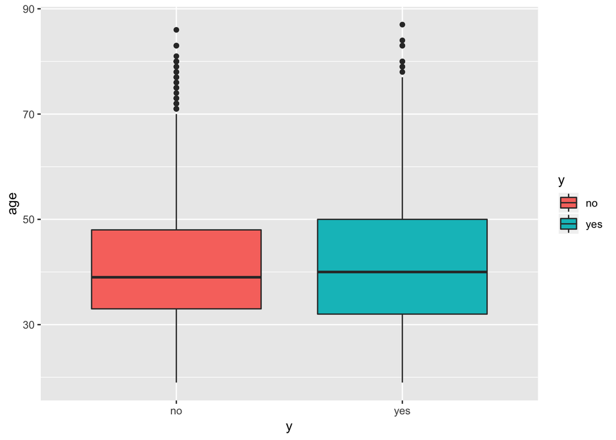

```r
banks %>% ggplot(aes(x=y, y=age, fill=y)) + geom_boxplot()
```

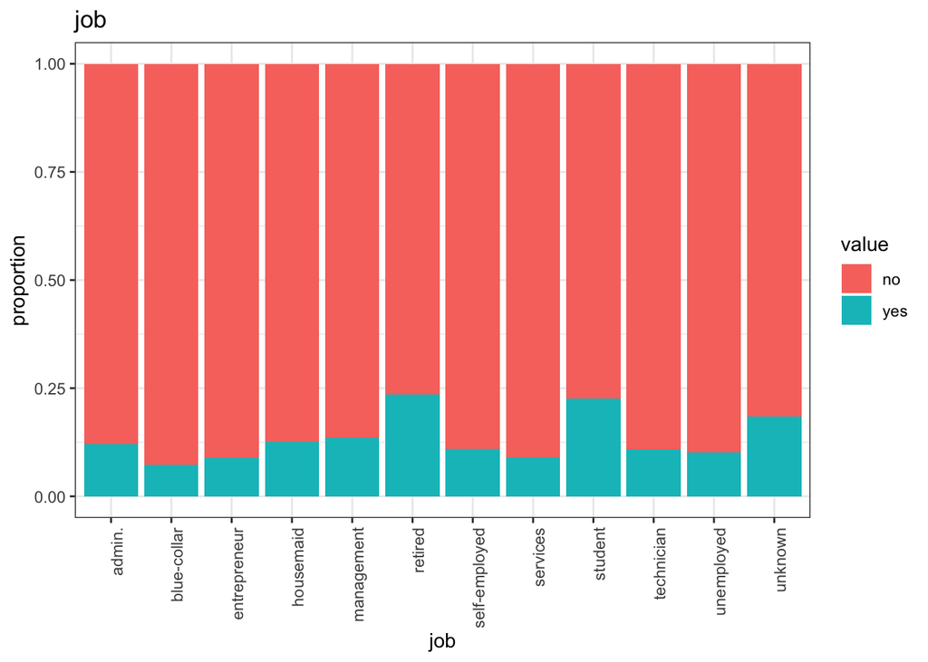

```r
banks %>% group_by(job) %>% summarise(yes=sum(y=="yes")/n(), no=sum(y=="no")/n()) %>% gather(value, proportion, -job) %>% ggplot(aes(x=job, y=proportion, fill=value)) + geom_bar(stat = "identity") + theme_bw() + theme(axis.text.x = element_text(angle = 90, hjust = 1)) + labs(title="job")
```

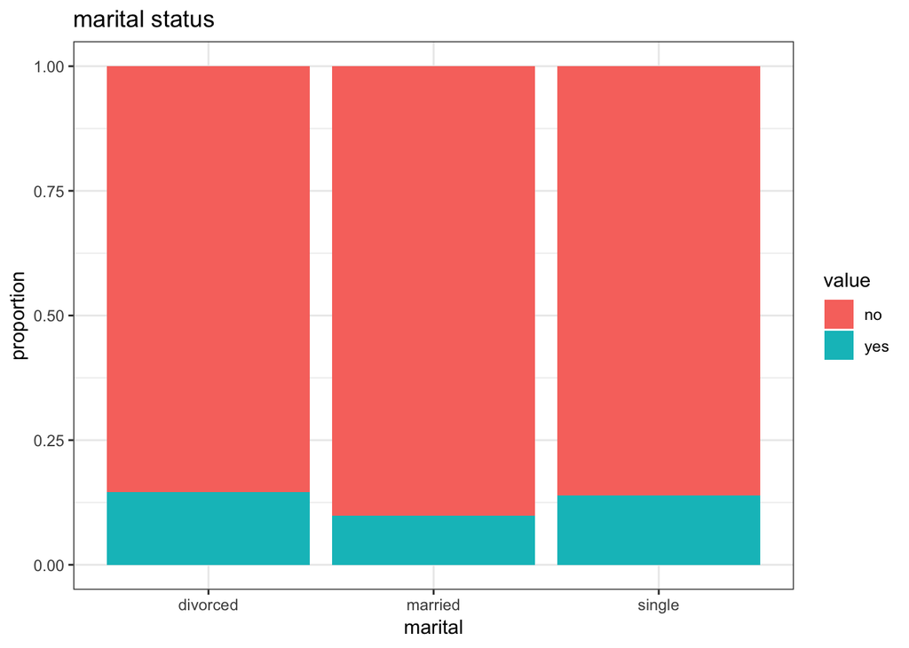

```r
banks %>% group_by(marital) %>% summarise(yes=sum(y=="yes")/n(), no=sum(y=="no")/n()) %>% gather(value, proportion, -marital) %>% ggplot(aes(x=marital, y=proportion, fill=value)) + geom_bar(stat = "identity") + theme_bw() + labs(title="marital status")
```

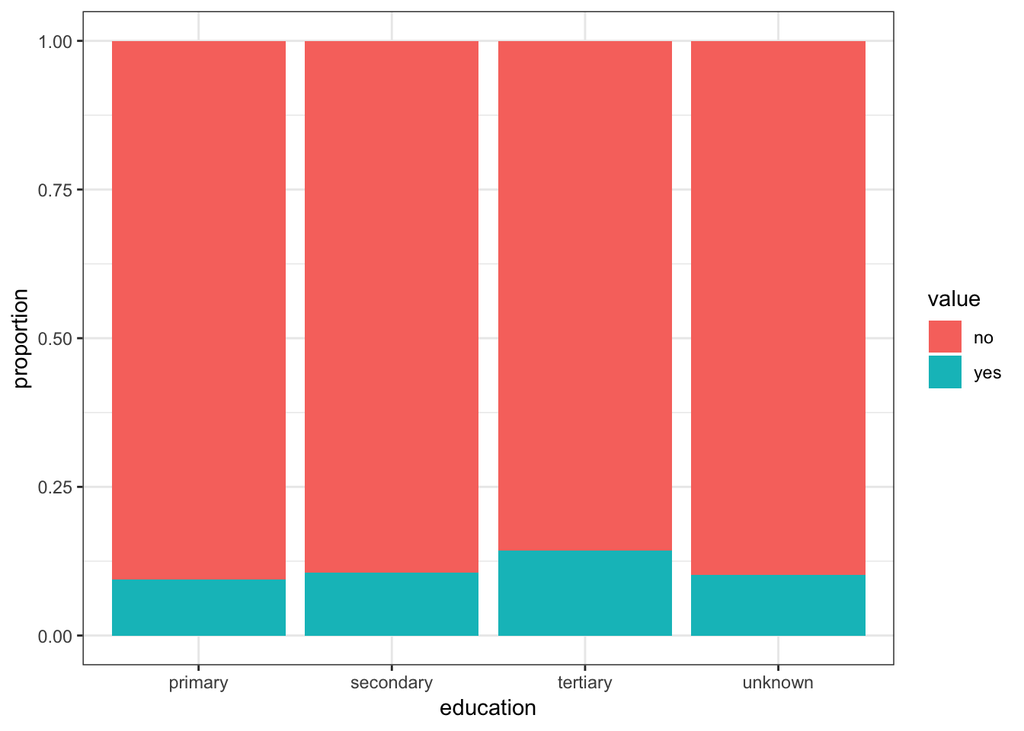

```r
banks %>% group_by(education) %>% summarise(yes=sum(y=="yes")/n(), no=sum(y=="no")/n()) %>% gather(value, proportion, -education) %>% ggplot(aes(x=education, y=proportion, fill=value)) + geom_bar(stat = "identity") + theme_bw() + labs("education")
```

### 3.1.2 Customer variables

Let’s examine the potential discriminant effect of customer variables:

```r
with(banks, table(default, y))
```

```
##        y
## default   no  yes
##     no  3933  512
##     yes   67    9
```

```r
with(banks, table(housing, y))
```

```
##        y
## housing   no  yes
##     no  1661  301
##     yes 2339  220
```

```r
with(banks, table(loan, y))
```

```
##      y
## loan    no  yes
##   no  3352  478
##   yes  648   43
```

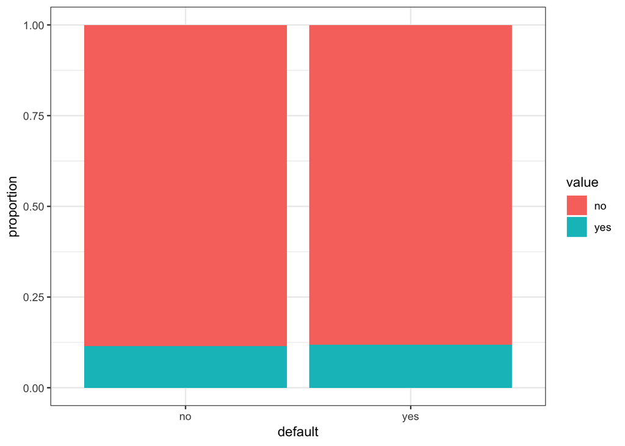

```r
banks %>% group_by(default) %>% summarise(yes=sum(y=="yes")/n(), no=sum(y=="no")/n()) %>% gather(value, proportion, -default) %>% ggplot(aes(x=default, y=proportion, fill=value)) + geom_bar(stat = "identity") + theme_bw()
```

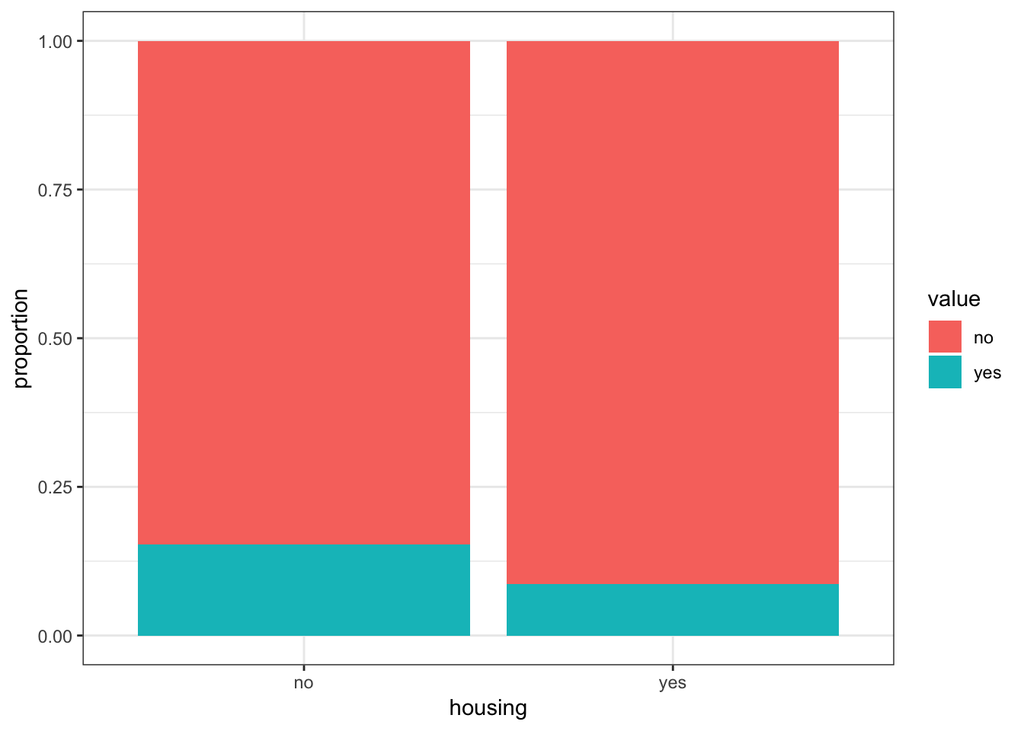

```r
banks %>% group_by(housing) %>% summarise(yes=sum(y=="yes")/n(), no=sum(y=="no")/n()) %>% gather(value, proportion, -housing) %>% ggplot(aes(x=housing, y=proportion, fill=value)) + geom_bar(stat = "identity") + theme_bw()
```

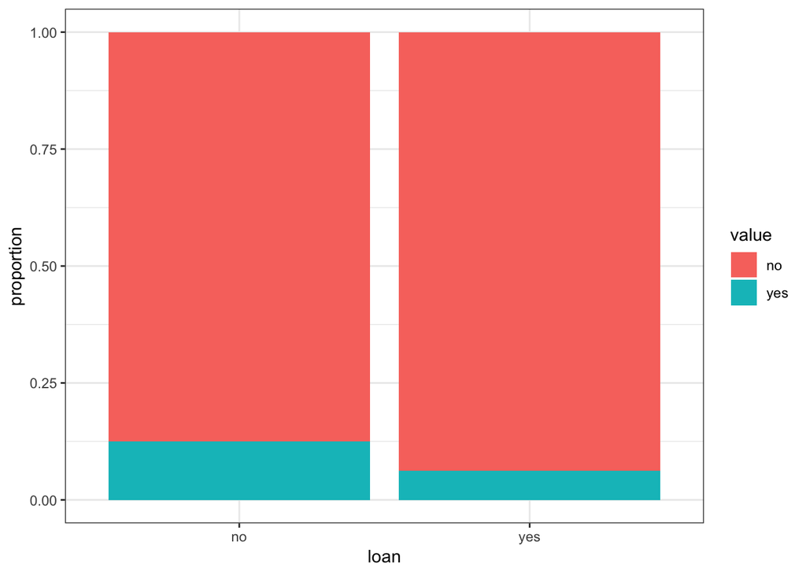

```r
banks %>% group_by(loan) %>% summarise(yes=sum(y=="yes")/n(), no=sum(y=="no")/n()) %>% gather(value, proportion, -loan) %>% ggplot(aes(x=loan, y=proportion, fill=value)) + geom_bar(stat = "identity") + theme_bw()
```

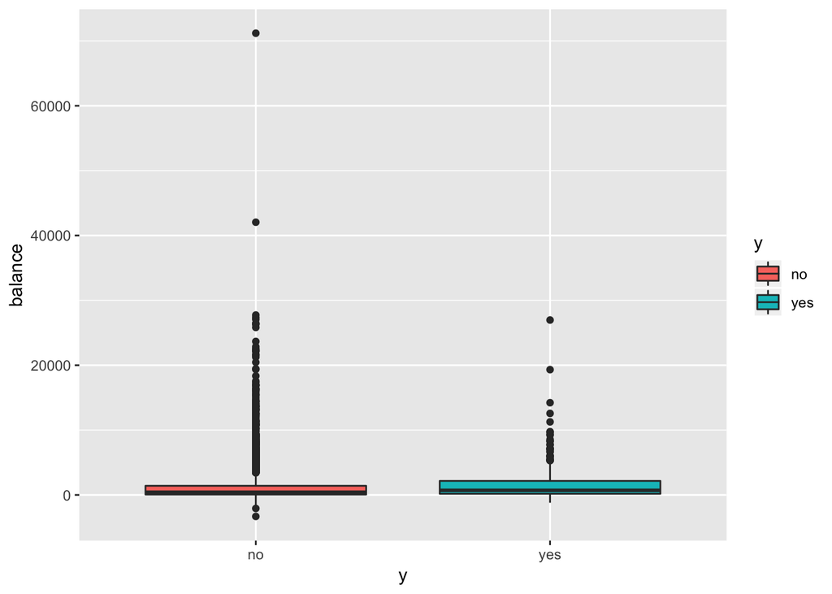

```r
banks %>% ggplot(aes(x=y, y=balance, fill=y)) + geom_boxplot()
```

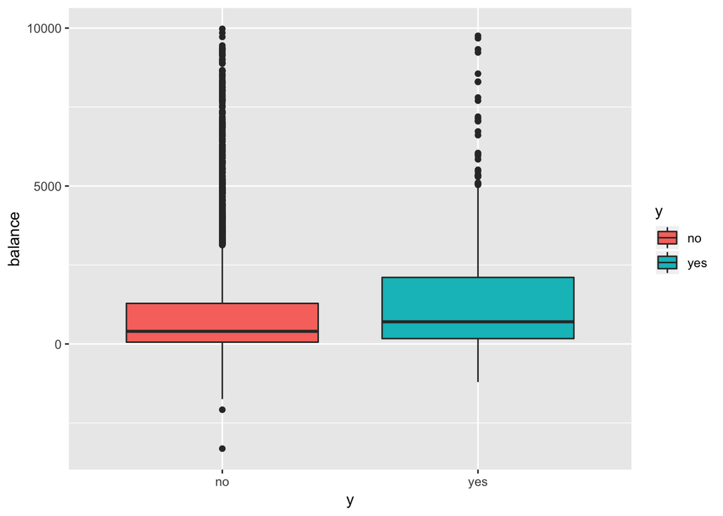

```r
banks %>% filter(balance<=10000) %>% ggplot(aes(x=y, y=balance, fill=y)) + geom_boxplot()
```

### 3.1.3 Campaign

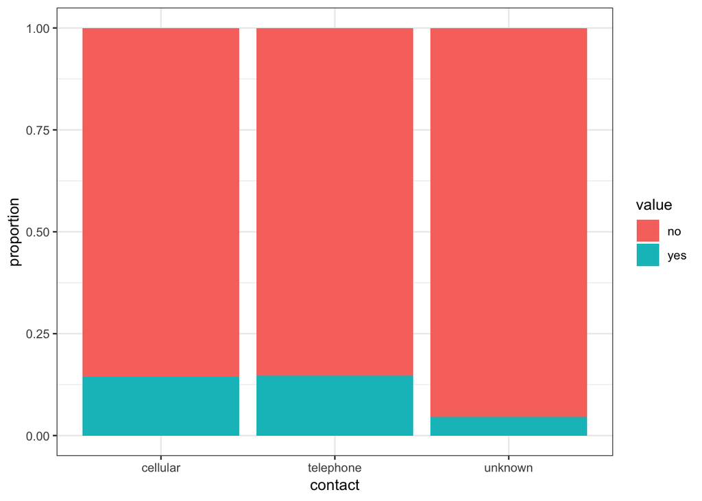

```r
banks %>% group_by(contact) %>% summarise(yes=sum(y=="yes")/n(), no=sum(y=="no")/n()) %>% gather(value, proportion, -contact) %>% ggplot(aes(x=contact, y=proportion, fill=value)) + geom_bar(stat = "identity") + theme_bw()
```

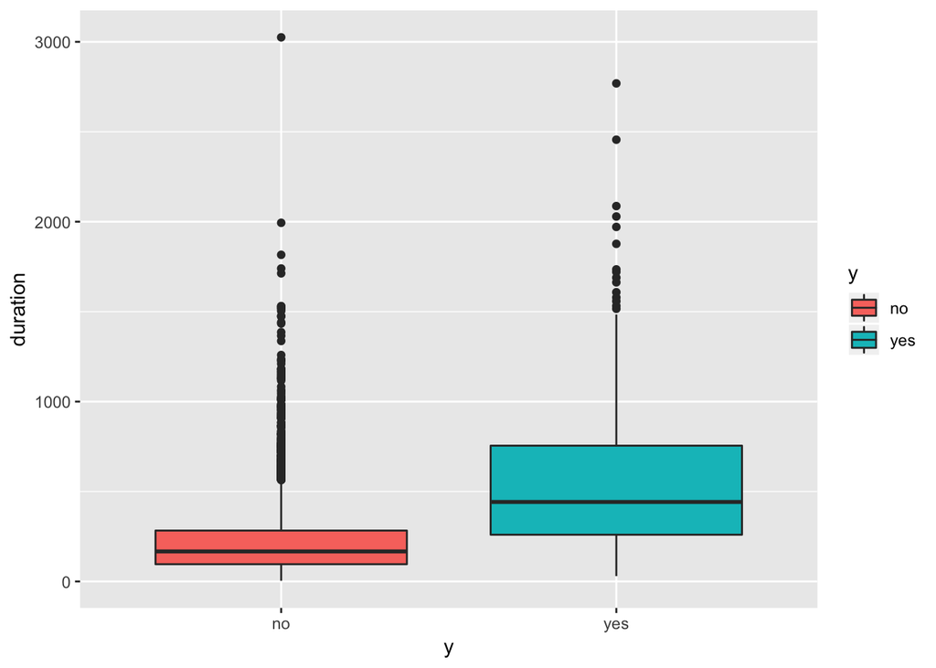

```r
banks %>% ggplot(aes(x=y, y=duration, fill=y)) + geom_boxplot()
```

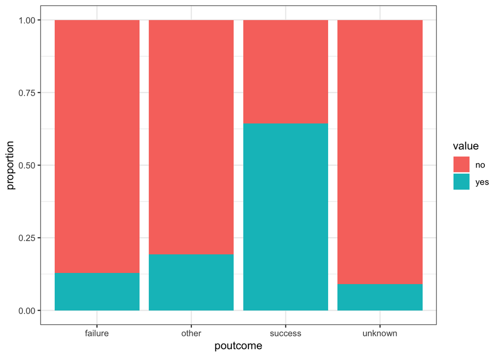

```r
banks %>% group_by(poutcome) %>% summarise(yes=sum(y=="yes")/n(), no=sum(y=="no")/n()) %>% gather(value, proportion, -poutcome) %>% ggplot(aes(x=poutcome, y=proportion, fill=value)) + geom_bar(stat = "identity") + theme_bw()
```

There are two groups in the sample:

- People not contacted in previous campaigns: they have `pdays=-1`, `previous=0` and `poutcome=unkown`. There are 3705 not contacted previously individuals.
- People contacted in previous campaigns. There are 816 previously contacted individuals.